# TP 2 - Logiciel statistique R

MOUSSA MAHAMADOU Oumar Farouk

2024-04-14

```r
library(tidyverse)
library(readxl) #lire des fichiers Excel
library(questionr) # exploitation des données d'enquêtes (fonctions de proportion)
library(kableExtra) #améliorer la présentation des tableaux
library(here) #gérer les chemins de fichiers et de répertoires
#library(labelled)
```

# 1 Importation et mise en forme

```r
# Définition du chemin d'acces

path=here("TP 2 - Logiciel statistique R/Donnees", "Base TP2.xlsx")

# importation de la base sous format excel

base_tp2 <- read_excel(path)

#class(base_tp2) "tbl_df"     "tbl"        "data.frame"
```

### 1.0.1 Donner le nombre de lignes et colonnes de la base

```r
# Nombre de lignes et de colonnes
dim(base_tp2)
```

```
## [1] 53 30
```

La base *base_tp2* comporte 53 observations et 30 variables.

# 2 Labelisation

Labelisation de toutes les variables de la base.

```r
base_tp2=base_tp2 |>
  #Donner une description aux variables
  expss::apply_labels(sexe="Sexe du producteur",
                     age="Age du producteur",
                     sit_mat="Situation maritale u producteur",
                     si_chef_men="Statut du producteur dans le ménage",
                     ethnie="Ethnie du producteur",
                     occupation="Occupation du producteur",
                     formation="statut de formation du producteur",
                     niveau_alphabs="Niveau d'alphabétisation du producteur",
                     types_varietes="Quelles sont les variétés
                     que vous utilisez pour la production du sésame ?",
                     criteres_var="Quels sont les critères de choix des variétés du sésame ?")
#View(base_tp2)
```

# 3 Recodage des modalites des variables

### 3.0.1 Sexe

```r
#base_tp2$sexe= labelled::labelled(base_tp2$sexe, labels =c(Homme=1, Femme=2))
```

```r
base_tp2$sexe=dplyr::recode(as.character(base_tp2$sexe),
                                  "1" = "Homme", "2" = "Femme")

table(base_tp2$sexe)
```

```
##
## Femme Homme
##    18    35
```

### 3.0.2 Situation maritale

```r
base_tp2$sit_mat=dplyr::recode(as.character(base_tp2$sit_mat),
                                               "1"="Marie(e)",
                                               "3"="Veuf(ve)",
                                               "4"="Divorcé(e)",
                                               "5"="Séparé(e)",
                                              "6"="Célibataire")
table(base_tp2$sit_mat)
```

```
##
## Marie(e) Veuf(ve)
##       51        2
```

### 3.0.3 Statut dans le ménage (si_chef_men)

```r
base_tp2$si_chef_men=dplyr::recode(as.character(base_tp2$si_chef_men),
                                   "1"="femme du chef de ménage",
                                   "2"="chef de ménage",
                                   "3"="fils-fille du chef de ménage" ,
                                   "99"="Autres")
table(base_tp2$si_chef_men)
```

```
##
##               chef de ménage      femme du chef de ménage
##                           28                           16
## fils-fille du chef de ménage
##                            9
```

### 3.0.4 Ethnie du producteur

```r
base_tp2$ethnie=dplyr::recode(as.character(base_tp2$ethnie),   "1"="Wolof",
                                                               "2"="Pulaar/Toucouleur",
                                                               "3"="Sérère",
                                                               "4"="Mandika/Bambara",
                                                               "5"="Soninké",
                                                               "6"="Diola",
                                                               "7"="Manjack",
                                                               "8"="Bainouk",
                                                               "9"="Maures",
                                                               "10"="Balante",
                                                              "77"= "Autre" )
table(base_tp2$ethnie)
```

```
##
##             Autre           Balante             Diola   Mandika/Bambara
##                11                 3                 1                 8
## Pulaar/Toucouleur            Sérère             Wolof
##                 7                13                10
```

## 3.1 Statut de formation du producteur

```r
base_tp2$formation=dplyr::recode(as.character(base_tp2$formation),"1"="Non scolarisé",
                                                                  "2"="Elementaire",
                                                                  "3"="Moyen" ,
                                                                  "4"= "Secondaire",
                                                                  "5"="Licence",
                                                                  "6"= "Master",
                                                                  "7"="Doctorat",
                                                                  "99"= "Ne sait pas")
table(base_tp2$formation)
```

```
##
##   Elementaire       Licence         Moyen   Ne sait pas Non scolarisé
##            10             2             7             1            30
##    Secondaire
##             3
```

## 3.2 Niveau d’alphabétisation du producteur

```r
base_tp2$niveau_alphabs=dplyr::recode(as.character(base_tp2$niveau_alphabs),
                                      "0"="Sans niveau",
                                      "1"="Sait lire dans une langue",
                                      "2"="Sait lire et écrire dans une langue")
table(base_tp2$formation)
```

```
##
##   Elementaire       Licence         Moyen   Ne sait pas Non scolarisé
##            10             2             7             1            30
##    Secondaire
##             3
```

La structure des variables **occupation**, **types_varietes**, **criteres_var** ne permet pas de les recoder.

# 4 Analyses descriptives

## 4.1 Statistiques univariées

### 4.1.1 Sexe

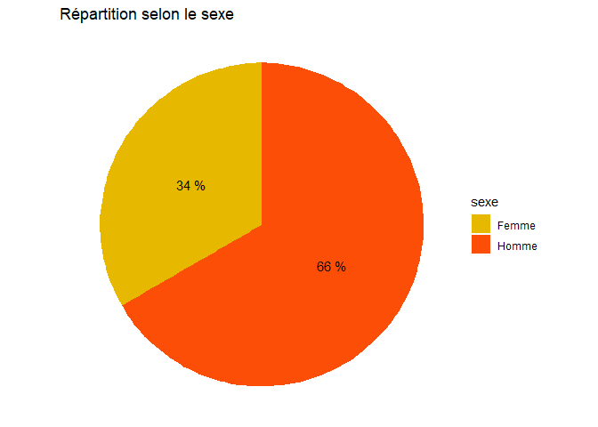

```r
# Création du dataframe avec les catégories de sexe et leurs proportions
df_prop_sexe <- data.frame(
   sexe = names(table(base_tp2$sexe)),
  proportion = paste((round((table(base_tp2$sexe) / sum(table(base_tp2$sexe))), digits=3)*100), "%")
)

# diagramme circulaire
#palette de couleur
pal=c("#E7B800", "#FC4E07")

ggplot(df_prop_sexe, aes(x="", y=proportion, fill=sexe, label=proportion)) +

  #création d'un diagramme en barres
  geom_bar(stat="identity", width=1) +

  #onvertion le graphique en coordonnées polaires
  coord_polar("y", start=0) +

  #ajout des étiquettes de texte au graphique
  geom_text(position = position_stack(vjust = 0.5)) +

  #définir les titree du graphique et de la légende
  labs(title="Répartition selon le sexe", colour="Sexe") +

  #supprimer tous le thème par défaut
  theme_void() +

  #définition les couleurs
  scale_fill_manual(values = pal)
```

A travers le graphique, on note que les hommes répresentent 66% des producteurs.

### 4.1.2 Age

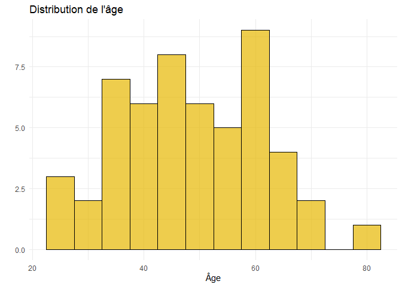

```r
# Création de l'histogramme de l'âge
ggplot(base_tp2, aes(x=age)) +
  geom_histogram(
                 fill="#E7B800",
                 color="black",
                 alpha=0.7,
                 binwidth = 5) + # binwidth= largeur de chaque barre
  labs(title="Distribution de l'âge", x="Âge", y="") +
  theme_minimal()
```

### 4.1.3 Situation maritale du producteur

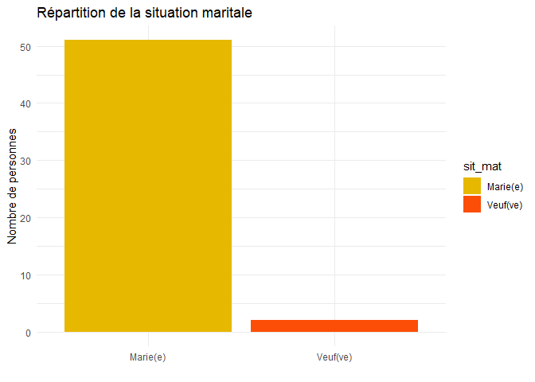

```r
pal=c("#E7B800", "#FC4E07")
ggplot(base_tp2, aes(x=sit_mat, fill=sit_mat)) +
  geom_bar() +
  labs(title="Répartition de la situation maritale",
       x="",
       y="Nombre de personnes",
       colour="Situation maritale") +
  scale_fill_manual(values = pal)+  # Utilisation d'une palette de couleurs
  theme_minimal()
```

### 4.1.4 Ethnie

```r
#Création du dataframe avec les catégories de l'ethnie et leurs proportions

df_prop_ethnie <- data.frame(
   ethnie = names(table(base_tp2$ethnie)),
   #création de variable proportion qui contient les proportions en % des ethnies
  proportion = paste0((round((table(base_tp2$ethnie) / sum(table(base_tp2$ethnie))), digits=3)*100), "%") #
)

ggplot(df_prop_ethnie, aes(x="", y=proportion, fill=ethnie, label=proportion)) +
  geom_bar(stat="identity", width=1) + # crée un diagramme en barres
  #convertir le graphique en coordonnées polaires ("y" : La transformation de l'axe y)
  coord_polar("y", start=0) + # start=0 : L'angle de départ pour les barres est défini à 0 degré

  #ajout des étiquettes de texte au graphique
  geom_text(position = position_stack(vjust = 0.5)) +
  labs(title="Répartition des ethnies") +
  theme_void()  # supprimer les éléments du thème par défaut
```

[figure not shown]

### 4.1.5 Statut de formation du producteur

```r
#calcul de proportion des occurences
tb=questionr::freq(base_tp2$formation, valid = FALSE, total = TRUE)
tb %>%
  #titre du tableau
  kbl(caption = "Distribution selon la formation") %>%
  #mise en forme du tableau
  kable_classic(full_width = F, html_font = "Cambria", font_size = 20)
```

Distribution selon la formation

|  | n | % |
| --- | --- | --- |
| Elementaire | 10 | 18.9 |
| Licence | 2 | 3.8 |
| Moyen | 7 | 13.2 |
| Ne sait pas | 1 | 1.9 |
| Non scolarisé | 30 | 56.6 |
| Secondaire | 3 | 5.7 |
| Total | 53 | 100.0 |

Selon les résulats, 56,6% des producteurs ne sont pas scolarisés. Seulement 3,8% des producteurs ont atteint la licence.

## 4.2 Statistiques bivariées

## 4.3 Age et sexe

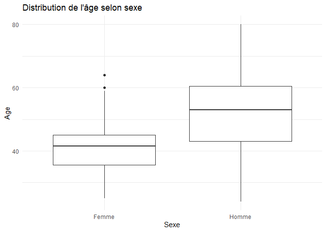

```r
ggplot(base_tp2, aes(x=sexe, y=age)) +
  geom_boxplot() +
  labs(title="Distribution de l'âge selon sexe",
       x="Sexe",
       y="Age")+
  theme_minimal()
```

On note une disparité des ages dans la distribution des produteurs. En effet, 50% des producteurs de sexe féminin ont moins de 42 ans alors que chez les hommes, les 50% ont plus de 52 ans.

## 4.4 Formation et sexe

Distribution de la formation par rapport au sexe

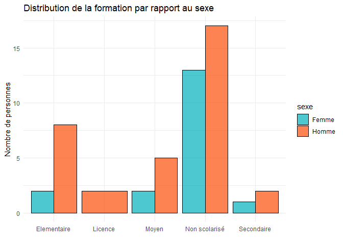

```r
palette=c("#00AFBB", "#FC4E07")
base_tp2 |>
  filter(formation!="Ne sait pas") |>

ggplot( aes(x=formation, fill=sexe)) +
  geom_bar(position="dodge", color="black", alpha=0.7) +
  labs(title="Distribution de la formation par rapport au sexe",
       x="",
       y="Nombre de personnes") +
  theme_minimal()+
  scale_fill_manual(values = palette)
```

## 4.5 Situation maritale et le statut dans le ménage

Tableau croisé entre la situation maritale et le statut dans le ménage

```r
# Création du tableau croisé
tab <- table(base_tp2$sit_mat, base_tp2$si_chef_men)


# Affichage du tableau avec kableExtra
  round(cprop(tab), digits = 1)|>
    #titre du tableau
  kbl(caption = "La situation maritale et le statut dans le ménage") |>
    #mise en forme du tableau
  kable_classic(full_width = F, html_font = "Cambria", position="left")
```

La situation maritale et le statut dans le ménage

|  | chef de ménage | femme du chef de ménage | fils-fille du chef de ménage | Ensemble |
| --- | --- | --- | --- | --- |
| Marie(e) | 100 | 87.5 | 100 | 96.2 |
| Veuf(ve) | 0 | 12.5 | 0 | 3.8 |
| Total | 100 | 100.0 | 100 | 100.0 |

## 4.6 Formation et type de variété

### 4.6.1 Test 1

L’hypothèse nulle : « les variables *formation* et *types_variete_1* (traditionnelle) sont indépendantes ».

```r
chi_table1=table( base_tp2$types_varietes_1, base_tp2$formation)
test1=chisq.test(chi_table1)

#test1$statistic # la statistique du Chi2.
#test1$parameter # le nombre de degr?s de libert?s.
test1$p.value # la p-value.
```

```
## [1] 0.5793323
```

La p-valeur qui est de 0.5793323 est supérieur à 5%, on peut donc accepte l’hypothèse selon laquelle les deux variables testées sont indépendantes. Par conséquent, nous ne disposons pas de suffisamment de preuves pour affirmer que le choix de la variété de type traditionnelle dépend du niveau de formation du producteur.”

### 4.6.2 Test 2

```r
chi_table2=table( base_tp2$types_varietes_2, base_tp2$formation)
test2=chisq.test(chi_table2)

#test1$statistic # la statistique du Chi2.
#test2$parameter # le nombre de degr?s de libert?s.
test2$p.value # la p-value.
```

```
## [1] 0.02516851
```

Pour le test 2, la p-valeur est de 0.02516851, ce qui est inférieur à 5%. Par conséquent, nous rejetons l’hypothèse nulle d’indépendance entre les variables. On peut en déduire que l’utilisation de la variété améliorée pour la production de semences dépend du niveau de formation atteint par le producteur.